# TSA Forecasting_report_top5

Bruce Chen, Jeffery Chu

2026-04-23

> Summary of results: The TBATS model achieved the best performance due to its ability to capture multiple seasonal patterns in daily electricity demand. Other models incorporating exogenous variables did not significantly improve accuracy. Model performance rank from best to worst:
> 1. TBATS
> 2. SARIMAX
> 3. STLM
> 4. MSTL_ETS
> 5. ARIMA + Fourier

> Github links: https://github.com/Parautilitarian/TSA_Load_Forecasting

```r
library(lubridate)
```

```r
library(ggplot2)
library(forecast)
library(Kendall)
library(tseries)
library(outliers)
library(tidyverse)
library(readxl)
library(forecast)
```

## 1. Load Dataset

#### Preprocessing

```r
load <- read_excel("load.xlsx")
head(load)
```

```
## # A tibble: 6 × 26
##   meter_id date                   h1    h2    h3    h4    h5    h6    h7    h8
##   <chr>    <dttm>              <dbl> <dbl> <dbl> <dbl> <dbl> <dbl> <dbl> <dbl>
## 1 0072     2005-01-01 00:00:00  3072  2911  2784  2768  2832  2904  3064  3192
## 2 0072     2005-01-02 00:00:00  2408  2328  2311  2328  2400  2552  2856  3272
## 3 0072     2005-01-03 00:00:00  2575  2528  2496  2608  2825  3376  3760  3672
## 4 0072     2005-01-04 00:00:00  2177  2016  1951  1913  2080  2624  3328  2896
## 5 0072     2005-01-05 00:00:00  1912  1768  1697  1720  1880  2472  3208  2888
## 6 0072     2005-01-06 00:00:00  2104  1976  1920  1952  2167  2736  3432  3096
## # ℹ 16 more variables: h9 <dbl>, h10 <dbl>, h11 <dbl>, h12 <dbl>, h13 <dbl>,
## #   h14 <dbl>, h15 <dbl>, h16 <dbl>, h17 <dbl>, h18 <dbl>, h19 <dbl>,
## #   h20 <dbl>, h21 <dbl>, h22 <dbl>, h23 <dbl>, h24 <dbl>
```

#### Convert Hourly to Daily

```r
daily_load <- load %>%
  rowwise() %>%
  mutate(daily_load = mean(c_across(starts_with("h")), na.rm = TRUE)) %>%
  ungroup() %>%
  select(date, daily_load)

daily_load$date <- as.Date(daily_load$date)
```

#### Train-Validation Split

```r
train_data <- daily_load %>%
  filter(date <= as.Date("2010-06-30"))

valid_data <- daily_load %>%
  filter(date >= as.Date("2010-07-01") &
         date <= as.Date("2010-07-31"))

train_msts <- msts(
  train_data$daily_load,
  seasonal.periods = c(7, 365),
  start = c(2005, 1)
)

train_ts <- ts(train_data$daily_load,
               start = c(2005,1),
               frequency = 365)

valid_msts <- msts(
  valid_data$daily_load,
  seasonal.periods = c(7, 365),
  start = c(2010, 182)
)

valid_ts <- ts(valid_data$daily_load,
               start = c(2010,7),
               frequency = 365)
```

#### Decomposition

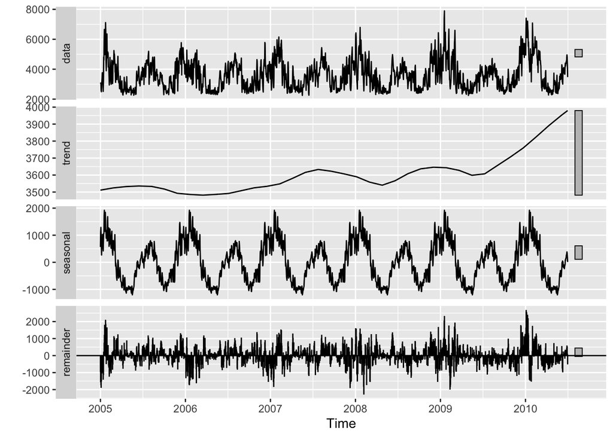

```r
decomp <- stl(train_ts, s.window = "periodic")
autoplot(decomp) # seasonal
```

## 2. Model 1 - TBATS (Baseline Model)

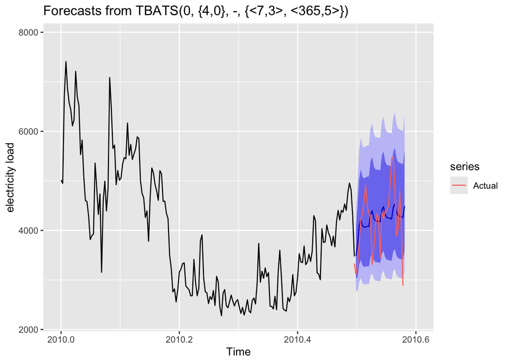

```r
fit_tbats <- tbats(train_msts)
forecast_tbats <- forecast(fit_tbats, h = length(valid_msts))

autoplot(forecast_tbats) +
  autolayer(valid_msts, series = "Actual", PI = FALSE) +
  xlim(2010, 2010.6) +
  ylab("electricity load")
```

```r
summary(fit_tbats)
```

```
##                   Length Class  Mode
## lambda                1  -none- numeric
## alpha                 1  -none- numeric
## beta                  0  -none- NULL
## damping.parameter     0  -none- NULL
## gamma.one.values      2  -none- numeric
## gamma.two.values      2  -none- numeric
## ar.coefficients       4  -none- numeric
## ma.coefficients       0  -none- NULL
## likelihood            1  -none- numeric
## optim.return.code     1  -none- numeric
## variance              1  -none- numeric
## AIC                   1  -none- numeric
## parameters            2  -none- list
## seed.states          21  -none- numeric
## fitted.values      2007  msts   numeric
## errors             2007  msts   numeric
## x                 42147  -none- numeric
## seasonal.periods      2  -none- numeric
## k.vector              2  -none- numeric
## y                  2007  msts   numeric
## p                     1  -none- numeric
## q                     1  -none- numeric
## call                  2  -none- call
## series                1  -none- character
## method                1  -none- character
```

```r
accuracy(forecast_tbats, valid_msts)
```

```
##                    ME     RMSE      MAE        MPE      MAPE      MASE
## Training set 29.98179 423.5522 313.6325 -0.3333858  8.518809 0.4442748
## Test set     11.41074 561.2408 429.5423 -1.6755046 10.665483 0.6084665
##                    ACF1 Theil's U
## Training set 0.02262869        NA
## Test set     0.48200168  1.030122
```

## 3. Temperature Dataset

#### Preprocessing

```r
# load data
temperature <- read_excel("temperature.xlsx")
head(temperature)
```

```
## # A tibble: 6 × 30
##   date                   hr t_ws1 t_ws2 t_ws3 t_ws4 t_ws5 t_ws6 t_ws7 t_ws8
##   <dttm>              <dbl> <dbl> <dbl> <dbl> <dbl> <dbl> <dbl> <dbl> <dbl>
## 1 2005-01-01 00:00:00     1    43    46    40    47    48    46    44    52
## 2 2005-01-01 00:00:00     2    41    46    38    46    48    45    51    50
## 3 2005-01-01 00:00:00     3    40    46    37    45    45    45    49    48
## 4 2005-01-01 00:00:00     4    39    46    37    47    48    48    45    50
## 5 2005-01-01 00:00:00     5    38    46    37    44    48    49    43    50
## 6 2005-01-01 00:00:00     6    37    45    36    45    48    48    40    50
## # ℹ 20 more variables: t_ws9 <dbl>, t_ws10 <dbl>, t_ws11 <dbl>, t_ws12 <dbl>,
## #   t_ws13 <dbl>, t_ws14 <dbl>, t_ws15 <dbl>, t_ws16 <dbl>, t_ws17 <dbl>,
## #   t_ws18 <dbl>, t_ws19 <dbl>, t_ws20 <dbl>, t_ws21 <dbl>, t_ws22 <dbl>,
## #   t_ws23 <dbl>, t_ws24 <dbl>, t_ws25 <dbl>, t_ws26 <dbl>, t_ws27 <dbl>,
## #   t_ws28 <dbl>
```

```r
# convert hourly to daily
temp_daily <- temperature %>%
  mutate(date = as.Date(date, format="%d%b%Y")) %>%
  group_by(date) %>%
  summarise(across(-hr, mean, na.rm = TRUE))
# split train data
temp_train <- temp_daily %>%
  filter(date <= as.Date("2010-06-30"))

# convert to time series
temp_train_ts <- ts(
  temp_train[,-1],
  start = c(2005,1),
  frequency = 365
)
```

#### Determining each station’s level of correlations with load

```r
cors <- cor(train_ts, temp_train_ts, use="complete.obs")
sort(cors, decreasing = TRUE)
```

```
##  [1] -0.4136529 -0.4187522 -0.4362185 -0.4365159 -0.4408861 -0.4442132
##  [7] -0.4447486 -0.4498241 -0.4505035 -0.4506287 -0.4519990 -0.4528129
## [13] -0.4545288 -0.4559035 -0.4571899 -0.4572746 -0.4576779 -0.4594995
## [19] -0.4598152 -0.4603253 -0.4612840 -0.4613919 -0.4626571 -0.4635158
## [25] -0.4641586 -0.4670773 -0.4680701 -0.4690951
```

- **All correlations are around -0.41 to -0.47. That means:**
  - **Temperature and load are moderately negatively correlated.**
  - **The stations behave very similarly (only ~0.05 difference between best and worst).**

```r
# average all station data since their correlations are similar
temp_avg_ts <- ts(
  rowMeans(temp_train_ts, na.rm = TRUE),
  start = start(temp_train_ts),
  frequency = frequency(temp_train_ts)
)
```

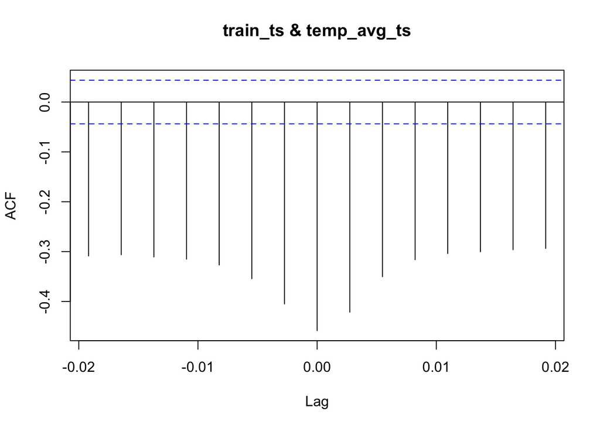

```r
ccf(train_ts, temp_avg_ts, lag.max = 7)
```

**Investigating correlations between average temperature and a lagged load series showed no** **improvement in correlations.**